# Analyse univariee du proteome

# Chargement des librairies

```r
library(knitr)

library(multcomp)

library(ggplot2)

library(ggpubr)
```

# Import des donnees

```r
table1<-read.table("C:/Users/Gardette/Documents/APT/2A/Big Data/Proteome/proteome_Ath.csv", sep=";", dec=".", header=T,row.names=1)
```

# Preparation des donnees

## Transformation centree-reduite des valeurs individuelles du tableau

```r
table1<-scale(table1)
```

## Ajout d’un facteur de groupe pour definir les echantillons

```r
temperature<-factor(rep(c("Low","Medium","Elevated"),each=3),levels=c("Low","Medium","Elevated"))

table2<-cbind.data.frame(temperature,table1)
```

# Representation graphique des variables

## Boxplot sur toutes les variables (724 proteines quantifiees)

```r
# fichier pdf ecrit dans le repertoire de travail

pdf("boxplot_proteome_724_proteines.pdf")

for(i in 2:ncol(table2)) {

  varname <- colnames(table2[i])

  g <-
    ggplot(table2, aes(fill = temperature)) +
    geom_boxplot(aes_string(x = temperature, y = table2[, i])) +
    labs(title = varname, x = "temperature conditions", y = "protein abundance") +
    theme(plot.title = element_text(
      colour = "red",
      size = 30,
      hjust = 0.5
    )) +
    theme(axis.title.x = element_text(colour = "black", size = 15)) +
    theme(axis.title.y = element_text(colour = "black", size = 15)) +
    theme(axis.text.x = element_text(colour = "black", size = 15)) +
    theme(axis.text.y = element_text(colour = "black", size = 10)) +
    scale_fill_manual(
      breaks = c("Low", "Medium", "Elevated"),
      values = c("lightblue", "lightgreen", "orange")
    )

  print(g)

}

dev.off()
```

## Exemple de boxplot

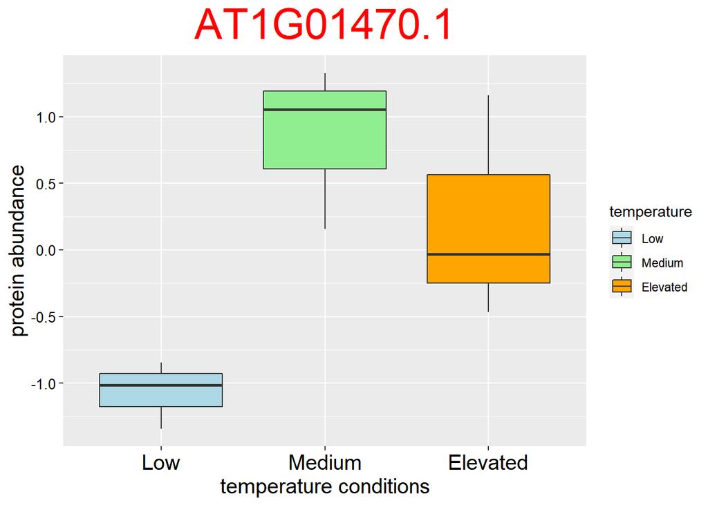

```r
i=2

varname<-colnames(table2[i])

g <- ggplot(table2, aes(fill = temperature)) +
  geom_boxplot(aes_string(x = temperature, y = table2[, i])) +
  labs(title = varname, x = "temperature conditions", y = "protein abundance") +
  theme(plot.title = element_text(
    colour = "red",
    size = 30,
    hjust = 0.5
  )) +
  theme(axis.title.x = element_text(colour = "black", size = 15)) +
  theme(axis.title.y = element_text(colour = "black", size = 15)) +
  theme(axis.text.x = element_text(colour = "black", size = 15)) +
  theme(axis.text.y = element_text(colour = "black", size = 10)) +
  scale_fill_manual(
    breaks = c("Low", "Medium", "Elevated"),
    values = c("lightblue", "lightgreen", "orange")
  )

print(g)
```

# Analyse de variance sur chaque variable

## Anova

```r
pvalue_anova<- c()

for(i in 2:ncol(table2)) {

  res_anova <- aov(table2[,i] ~ temperature, data = table2)
  paramANOVA <- summary(res_anova)
  pvalue_anova[i] <- paramANOVA[[1]][, 5][1]

}

names(pvalue_anova) <- colnames(table2)

kable(pvalue_anova[2:11])
```

|  | x |
| --- | --- |
| AT1G01470.1 | 0.0235043 |
| AT1G01900.1 | 0.0520424 |
| AT1G02700.1 | 0.1982042 |
| AT1G02780.1 | 0.2716566 |
| AT1G03030.1 | 0.0000199 |
| AT1G03880.1 | 0.3910705 |
| AT1G03890.1 | 0.0360564 |
| AT1G04170.1 | 0.0492476 |
| AT1G04410.1 | 0.4922254 |
| AT1G04480.1 | 0.0131701 |

## Distribution des p-values non corrigees

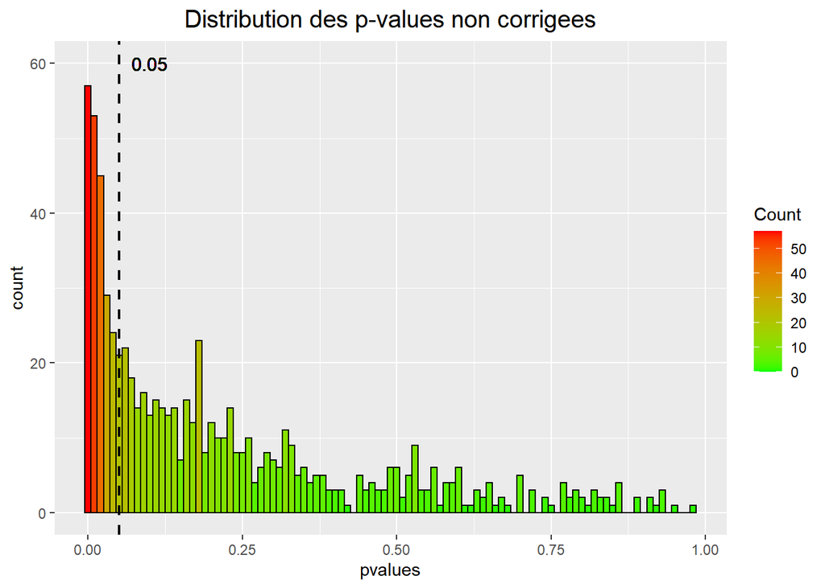

```r
df_pvalue <-
  data.frame(names = names(pvalue_anova), pvalues = pvalue_anova)

g <- ggplot(df_pvalue, aes(x = pvalues)) +
  geom_histogram(binwidth = 0.01, color = "black", aes(fill = ..count..)) +
  geom_vline(
    aes(xintercept = 0.05),
    colour = "black",
    linetype = "dashed",
    size = 0.75
  ) +
  geom_text(aes(x = 0.1, label = "0.05", y = 60),
            colour = "black",
            size = 4) +
  scale_fill_gradient("Count", low = "green", high = "red") +
  labs(title = "Distribution des p-values non corrigees") +
  theme(plot.title = element_text(
    colour = "black",
    size = 15,
    hjust = 0.5
  ))

print(g)
```

## Nombre de variables présentant des différences significatives

```r
liste1 <- na.omit(pvalue_anova[pvalue_anova<0.05])
length(liste1)
```

[1] 214

```r
liste2 <- na.omit(pvalue_anova[pvalue_anova<0.01])
length(liste2)
```

[1] 89

```r
liste3 <- na.omit(pvalue_anova[pvalue_anova<0.001])
length(liste3)
```

[1] 23

```r
names(liste3)
```

[1] “AT1G03030.1” “AT1G14950.1” “AT1G18500.1” “AT1G20620.1” “AT1G43670.1” “AT1G47980.1” “AT2G21660.1” “AT2G23110.1” “AT2G25970.1” “AT2G36640.1” “AT2G37970.1” “AT2G43520.1” “AT3G02480.1” “AT3G52850.1” “AT3G54400.1” “AT3G60730.1” “AT4G20360.1” “AT5G04885.1” “AT5G50250.1” “AT5G57550.1” “AT5G58070.1” [22] “AT5G66190.1” “AT5G66570.1”

## Correction des p-values pour tests multiples

```r
# utilisation d'une méthode FDR

pvalue_anova_adj <- p.adjust(pvalue_anova, method = "fdr")

kable(pvalue_anova_adj[2:11])
```

|  | x |
| --- | --- |
| AT1G01470.1 | 0.1132554 |
| AT1G01900.1 | 0.1697238 |
| AT1G02700.1 | 0.3283750 |
| AT1G02780.1 | 0.3871211 |
| AT1G03030.1 | 0.0039686 |
| AT1G03880.1 | 0.4856519 |
| AT1G03890.1 | 0.1373940 |
| AT1G04170.1 | 0.1666135 |
| AT1G04410.1 | 0.5808039 |
| AT1G04480.1 | 0.0908121 |

## Distribution des p-values corrigees

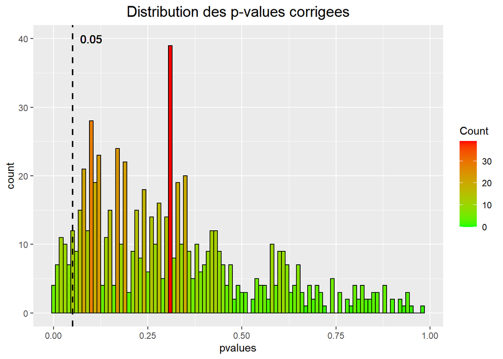

```r
df_pvalue_adj <-
  data.frame(names = names(pvalue_anova_adj), pvalues = pvalue_anova_adj)

g <- ggplot(df_pvalue_adj, aes(x = pvalues)) +
  geom_histogram(binwidth = 0.01, color = "black", aes(fill = ..count..)) +
  geom_vline(
    aes(xintercept = 0.05),
    colour = "black",
    linetype = "dashed",
    size = 0.75
  ) +
  geom_text(aes(x = 0.1, label = "0.05", y = 40),
            colour = "black",
            size = 4) +
  scale_fill_gradient("Count", low = "green", high = "red") +
  labs(title = "Distribution des p-values corrigees") +
  theme(plot.title = element_text(
    colour = "black",
    size = 15,
    hjust = 0.5
  ))

print(g)
```

## Application d’un filtre sur les p-values corrigees

```r
liste4 <- na.omit(pvalue_anova_adj[pvalue_anova_adj<0.05])

length(liste4)
```

[1] 44

```r
names(liste4)
```

[1] “AT1G03030.1” “AT1G09640.1” “AT1G11910.1” “AT1G14950.1” “AT1G17100.1” “AT1G18500.1” “AT1G19900.1” “AT1G20620.1” “AT1G43670.1” “AT1G47128.1” “AT1G47980.1” “AT1G64110.1” “AT1G65090.2” “AT2G05920.1” “AT2G21660.1” “AT2G21820.1” “AT2G23110.1” “AT2G25970.1” “AT2G28900.1” “AT2G36640.1” “AT2G37970.1” [22] “AT2G43520.1” “AT2G43950.1” “AT2G44060.1” “AT3G02480.1” “AT3G08030.1” “AT3G14067.1” “AT3G23570.1” “AT3G52850.1” “AT3G54400.1” “AT3G60730.1” “AT4G20360.1” “AT4G27520.1” “AT4G29840.1” “AT4G36360.1” “AT5G04885.1” “AT5G09640.1” “AT5G47810.1” “AT5G50250.1” “AT5G57550.1” “AT5G58070.1” “AT5G63800.1” [43] “AT5G66190.1” “AT5G66570.1”

# Comparaisons multiples : détailler les résultats de l’anova

## Realisation d’une comparaison entre groupe pris 2 à 2 : p-values

```r
tabmult = NULL

for (i in 2:ncol(table2)) {

  aov <- aov(table2[, i] ~ temperature, data = table2)
  multcomp <- TukeyHSD(aov)
  tabmult <- cbind(tabmult, multcomp$temperature [, 4])

}


vecteurNA<-rep("NA",nrow(tabmult))

tabmult2<-cbind.data.frame(vecteurNA,tabmult)

colnames(tabmult2)<-colnames(table2)

kable(tabmult2[,2:8])
```

|  | AT1G01470.1 | AT1G01900.1 | AT1G02700.1 | AT1G02780.1 | AT1G03030.1 | AT1G03880.1 | AT1G03890.1 |
| --- | --- | --- | --- | --- | --- | --- | --- |
| Medium-Low | 0.0211631 | 0.0597385 | 0.1808995 | 0.4477889 | 0.0109618 | 0.4894030 | 0.9454458 |
| Elevated-Low | 0.0959986 | 0.0983675 | 0.4567676 | 0.8989548 | 0.0000176 | 0.4219593 | 0.0442667 |
| Elevated-Medium | 0.4731432 | 0.9185182 | 0.7311059 | 0.2672072 | 0.0001480 | 0.9896561 | 0.0658099 |

## Graphes de Tukey : boxplots avec Compact Letter Display (cld)

```r
# fichier pdf ecrit dans le repertoire de travail

pdf("graphes_Tukey_proteome_724_proteines.pdf")

  for (i in 2:ncol(table2)) {

    varname <- colnames(table2[i])

    res_anova <- aov(table2[, i] ~ temperature, data = table2)
    tuk <- glht(res_anova, linfct = mcp(temperature = "Tukey"))

    CLD <- cld(tuk, level = 0.05)
    CLD <-
      data.frame(
        temperature = names(CLD$mcletters$Letters),
        lettres = CLD$mcletters$Letters
      )

    g <- ggplot(table2, aes(fill = temperature)) +
      geom_boxplot(aes_string(x = table2$temperature, y = table2[, i])) +

      labs(title = varname,
           x = "temperature conditions",
           y = "protein abondance") +

      theme_grey() +

      theme(plot.title = element_text(
        colour = "red",
        size = 20,
        hjust = 0.5
      )) +

      theme(axis.title.x = element_text(colour = "black", size = 15)) +
      theme(axis.title.y = element_text(colour = "black", size = 15)) +
      theme(axis.text.x = element_text(
        angle = 0,
        colour = "black",
        size = 15
      )) +
      theme(axis.text.y = element_text(colour = "black", size = 10)) +

      geom_text(
        data = CLD,
        aes(
          x = temperature,
          label = lettres,
          y = max(table2[, i]) + 0.1
        ),
        colour = "black",
        size = 6
      ) +

      scale_fill_manual(
        breaks = c("Low","Medium","Elevated"),
        values = c("lightblue", "lightgreen", "orange")
      )

    print(g)

  }

dev.off()
```

## Exemple pour une variable

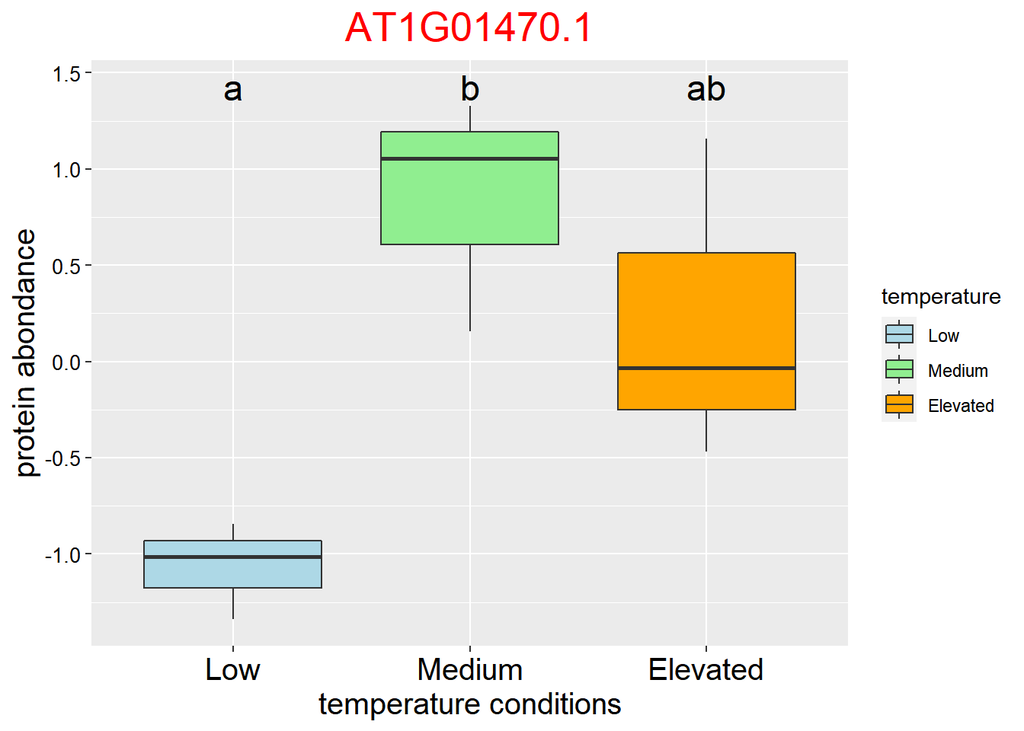

```r
i=2

varname <- colnames(table2[i])

res_anova <- aov(table2[, i] ~ temperature, data = table2)
tuk <- glht(res_anova, linfct = mcp(temperature = "Tukey"))

CLD <- cld(tuk, level = 0.05)
CLD <-
  data.frame(
    temperature = names(CLD$mcletters$Letters),
    lettres = CLD$mcletters$Letters
  )

g <- ggplot(table2, aes(fill = temperature)) +
  geom_boxplot(aes_string(x = table2$temperature, y = table2[, i])) +

  labs(title = varname,
       x = "temperature conditions",
       y = "protein abondance") +

  theme_grey() +

  theme(plot.title = element_text(
    colour = "red",
    size = 20,
    hjust = 0.5
  )) +

  theme(axis.title.x = element_text(colour = "black", size = 15)) +
  theme(axis.title.y = element_text(colour = "black", size = 15)) +
  theme(axis.text.x = element_text(
    angle = 0,
    colour = "black",
    size = 15
  )) +
  theme(axis.text.y = element_text(colour = "black", size = 10)) +

  geom_text(
    data = CLD,
    aes(
      x = temperature,
      label = lettres,
      y = max(table2[, i]) + 0.1
    ),
    colour = "black",
    size = 6
  ) +

  scale_fill_manual(
    breaks = c("Low","Medium","Elevated"),
    values = c("lightblue", "lightgreen", "orange")
  )

print(g)
```

## Recuperation de la matrice de Tukey des cld

```r
varname <- c()

matrice_tuk <- matrix()

for (i in 2:ncol(table2)) {

  varname <- colnames(table2[i])
  aov <- aov(table2[, i] ~ temperature, data = table2)
  tuk <- glht(aov, linfct = mcp(temperature = "Tukey"))
  out_cld <- cld(tuk, level = 0.05)
  matrice_tuk <-
    cbind.data.frame(matrice_tuk, out_cld$mcletters$Letters)

}

colnames(matrice_tuk) <- colnames(table2)

kable(matrice_tuk[,2:8])
```

|  | AT1G01470.1 | AT1G01900.1 | AT1G02700.1 | AT1G02780.1 | AT1G03030.1 | AT1G03880.1 | AT1G03890.1 |
| --- | --- | --- | --- | --- | --- | --- | --- |
| Low | a | a | a | a | a | a | b |
| Medium | b | a | a | a | b | a | ab |
| Elevated | ab | a | a | a | c | a | a |

## Recherche de variables presentant des profils de variation particuliers

```r
# exemple de filtrage de la matrice de Tukey contenant les cld

# ici recherche des profils "a","a","b" presentant un maximum d'abondance en condition "Elevated"

matrice_tuk_ftr<-matrice_tuk[,which(matrice_tuk[1,]=="a" & matrice_tuk[2,]=="a" & matrice_tuk[3,]=="b")]


# nb de variables presentant ce profil

dim(matrice_tuk_ftr)
```

[1] 3 25

```r
colnames(matrice_tuk_ftr)
```

[1] “AT1G04480.1” “AT1G09640.1” “AT1G20020.1” “AT1G47980.1” “AT1G68010.1” “AT2G21820.1” “AT2G23110.1” “AT2G30200.1” “AT2G32120.1” “AT2G36640.1” “AT2G43520.1” “AT2G44060.1” “AT3G08900.1” “AT3G12580.1” “AT3G22200.1” “AT3G23400.1” “AT3G23570.1” “AT3G58610.1” “AT4G21580.1” “AT4G24190.1” “AT4G29840.1” [22] “AT4G35090.1” “AT5G11520.1” “AT5G20720.1” “AT5G44120.3”

```r
kable(matrice_tuk_ftr[1:8])
```

|  | AT1G04480.1 | AT1G09640.1 | AT1G20020.1 | AT1G47980.1 | AT1G68010.1 | AT2G21820.1 | AT2G23110.1 | AT2G30200.1 |
| --- | --- | --- | --- | --- | --- | --- | --- | --- |
| Low | a | a | a | a | a | a | a | a |
| Medium | a | a | a | a | a | a | a | a |
| Elevated | b | b | b | b | b | b | b | b |

# Création du tableau de résultats final

```r
# calcul des moyennes d'abondance par temperature

matrice_moy <-
  aggregate(table2[, 2:ncol(table2)], by = list(table2$temperature), FUN =
              mean)

colnames(matrice_moy) <- colnames(table2)

row.names(matrice_moy) <-
  c("moyenne Low", "moyenne Medium", "moyenne Elevated")

table4 <-
  rbind.data.frame(
    round(matrice_moy[, -1], 3),
    "pvalue_anova" = round(pvalue_anova[-1], 3),
    "pvalue_anova_adj" = round(pvalue_anova_adj[-1], 3),
    round(tabmult2[, -1], 3),
    matrice_tuk[, -1]
  )

kable(table4[,1:8])
```

|  | AT1G01470.1 | AT1G01900.1 | AT1G02700.1 | AT1G02780.1 | AT1G03030.1 | AT1G03880.1 | AT1G03890.1 | AT1G04170.1 |
| --- | --- | --- | --- | --- | --- | --- | --- | --- |
| moyenne Low | -1.066 | 1.047 | -0.799 | 0.215 | -0.968 | -0.688 | 0.63 | -0.481 |
| moyenne Medium | 0.847 | -0.638 | 0.678 | -0.767 | -0.287 | 0.289 | 0.456 | -0.579 |
| moyenne Elevated | 0.219 | -0.41 | 0.121 | 0.552 | 1.255 | 0.4 | -1.086 | 1.06 |
| pvalue_anova | 0.024 | 0.052 | 0.198 | 0.272 | 0 | 0.391 | 0.036 | 0.049 |
| pvalue_anova_adj | 0.113 | 0.17 | 0.328 | 0.387 | 0.004 | 0.486 | 0.137 | 0.167 |
| Medium-Low | 0.021 | 0.06 | 0.181 | 0.448 | 0.011 | 0.489 | 0.945 | 0.984 |
| Elevated-Low | 0.096 | 0.098 | 0.457 | 0.899 | 0 | 0.422 | 0.044 | 0.079 |
| Elevated-Medium | 0.473 | 0.919 | 0.731 | 0.267 | 0 | 0.99 | 0.066 | 0.064 |
| Low | a | a | a | a | a | a | b | a |
| Medium | b | a | a | a | b | a | ab | a |
| Elevated | ab | a | a | a | c | a | a | a |

```r
# export du tableau final contenant toutes les donnees

write.table(
  table4,
  "tableau_final_univariee_proteome.csv",
  dec = ".",
  sep = ";",
  append = F,
  row.names = T,
  col.names = NA
)
```